# MUM 2024-25 Regularyzacja

## Problem i cel

- model jest budowany z wykorzystaniem dostępnych danych
  - dostępnych danych jest zwykle zbyt mało i budowa modelu z reguły prowadzi do jednego z dwóch problemów
    - **underfitting** gdy model zbytnio uogólnia
    - **overfitting** gdy model jest zbyt szczegółowy i zbyt dokładnie dopasowuje się do dostępnych danych overfitting
  - regularyzacja powinna poprawić **wynik na zbiorze testowym**, często kosztem danych treningowych

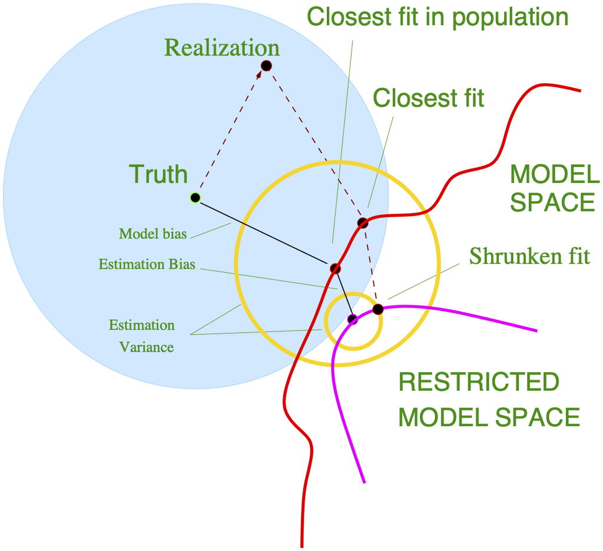

- regularyzacja może być
  - dodaniem pewnej wiedzy wstępnej *a priori* do modelu przez użycie założonego rozkładu parametrów
    - to ogranicza **pojemność modelu** jednocześnie ograniczając overfitting
    - patrz założenie o stacjonarności rozkładu parametrów w uczeniu Maximum a Posteriori MAP
  - ograniczeniem przestrzeni funkcji, np. ograniczenie użytych wykładników w aproksymacji wielomianowej
  - dowolną modyfikacją uczenia poprawiającą generalizację kosztem błędu uczenia (Ian Goodfellow)
- generalnie regularyzacja jest związana z ograniczeniem liczby parametrów
  - miary AIC (Akaike) i BIC (Bayesian) Information Criterion

#### uwaga

1. regularyzacja modyfikuje funkcję kosztu **tylko na zbiorze treningowym**
2. na **zbiorze testowym** sprawdzamy **oryginalną funkcję kosztu** (i ew. inne metryki, np. accuracy)

## Najpopularniejsze modele regularyzacji

- weight decay
- early stopping
- dropout
- batch normalization

## Podejścia do uczenia

- podstawy do podejść do uczenia w notebooku MLE i MAP

### Uczenie Maximum Likelihood Estimator (MLE)

- Szukamy takiego $w_\ast$, które zmaksymalizuje wartość liczbową likelihoodu: $$w_\ast = \underset{w}{\arg\max}\;p\,(D_{Tr}\mid{}w)$$
  - $w$ jest zestawem parametrów odpowiadającym przyjętej hipotezie
  - MLE szuka najlepszych parametrów z obserwowanych przykładów
  - w MLE funkcja kosztu estymuje jak rozkład predykcji modelu odpowiada rozkładowi danych uczących
  - MLE jest **spójny**: wraz ze wzrostem liczby przykładów uczących poprawia się estymacja parametrów modelu

### Uczenie Maximum a Posteriori (MAP)

1. $w$ - wektor wszystkich parametrów modelu
2. $L_{MLE}$ - funkcja kosztu negative mean log likelihood (z dokładnością do stałych)
3. $L_{MAP}$ - funkcja kosztu **negative mean log posterior** (z dokładnością do stałych)
- definiowana podobnie do $L_{MLE}$
- **ale** zamiast likelihood jest posterior
4. $L_{MAP}$ obliczany korzystając ze wzoru Bayesa $$\begin{align} p(w\mid D_{Tr}) &= \dfrac{p(D_{Tr}\mid{}w)p(w)}{p(D_{Tr})} \\ \log[p(w\mid D_{Tr})] &= \log[p(D_{Tr}\mid{}w)] + \log[p(w)] - \overbrace{\log[p(D_{Tr})]}^{const} \\ -\frac{1}{N}\log[p(w\mid D_{Tr})] &= -\frac{1}{N}\log[p(D_{Tr}\mid{}w)] -\frac{1}{N}\log[p(w)] + const \\ L_{MAP}(w) &= L_{MLE}(w) -\frac{1}{N}\log[p(w)] \end{align}$$
5. prosta reguła na regularyzację metodą MAP
- weź funkcję kosztu MLE
- dodaj składnik $-\frac{1}{N}\log[p(w)]$
  - **zależny od parametrów modelu** $w$
  - **niezależny od danych treningowych**

#### Uwaga

1. $L_{MLE}$ to **średnia** po $N$ przykładach
2. w takim razie $\log[p(w)]$ musi być podzielone przez $N$
- jeśli $N$ dąży do nieskończoności, to wpływ wiedzy a priori musi dążyć do zera
  - $1/N$ odpowiada współczynnikowi $\lambda$
3. niekiedy $\log[p(w)]$ nie jest dzielone przez $N$, ale wtedy funkcja kosztu to negative log likelihood, a nie negative **mean** log likelihood
- oba przypadki są równoważne

### Jak wybrać prior

- mamy pełną dowolność w zdefiniowaniu $p(w)$
  - ale tylko "dobry" prior pomoże w uczeniu
  - np. trzeba uważać, aby prior nie był zero dla żadnej sensownej hipotezy
- dobrze zdefiniować go tak, aby łatwo liczył się logarytm
  - funkcja $\exp$ w definicji gęstości — wtedy się wykasuje z logarytmem
  - współrzędne $w$ to zmienne niezależne — wtedy $\log[p(w)] = \sum_{t=1}^T\log[p(w)]$
- ważne są problemy dokładności i stabilności obliczeń

## Złożoność modelu a jego generalizacja

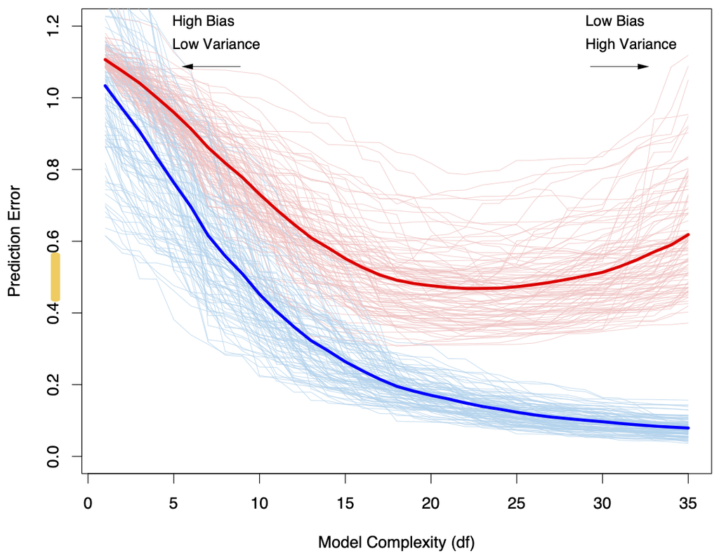

- generalizacja opisuje skuteczność modelu na przykładach spoza zbioru uczącego $$Err_{tst}=E[L(Y, f(x))\mid D_{tst}]$$
- $err$ to średni loss na zbiorze uczącym $D_{Tr}$
  - błąd na zbiorze uczącym nie jest dobrym estymatorem generalizacji
- rozkład błędu modelu $\hat{f}$ na *bias* i *wariancję*
  - niech szumem modelu będzie $\epsilon\sim\mathcal{N}(0,\sigma)$
- dla błędu kwadratowego \begin{align*} Err(\hat{f})&=E[(y-\hat{f})^2]&=E[y^2]-2E[y\hat{f}]+E[\hat{f}^2]\\ \\ &\textrm{gdzie poszczególne elementy}\\ E[y^2]&=E[(f+\epsilon)^2]=E[f^2]+2E[f\epsilon]+\epsilon^2\\ &=E[f^2]+2E[f]\cdot0+\epsilon^2&=f^2+\sigma^2\\ \\ &\textrm{dla każdej zmiennej losowej zachodzi}\\ Var(X)&=E[(X-E[X])^2]=E[X^2]-E[X]^2\\ &\textrm{stąd}\\ E[\hat{f}^2]&=&=Var(\hat{f})+E[\hat{f}]^2\\ \\ E[y\hat{f}]&=E[(f+\epsilon)\hat{f}]\\ &=E[f\hat{f}]+E[\epsilon\hat{f}]&=fE[\hat{f}]\\ \\ &\textrm{podstawiając}\\ Err[\hat{f}]&=f^2+\sigma^2-2fE[\hat{f}]+Var(\hat{f})+E[\hat{f}]^2\\ &=f^2-2f{}E[\hat{f}]+E[\hat{f}]^2+\sigma^2+Var(\hat{f})\\ &=(f-E[\hat{f}])^2+\sigma^2+Var(\hat{f})&=Bias[\hat{f}]^2+\sigma^2+Var(\hat{f}) \end{align*}

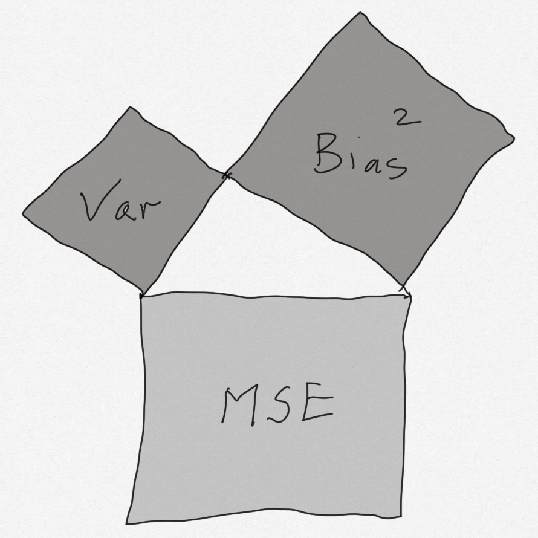

  - $\sigma^2$ jest nieredukowalnym składnikiem błędu, niemożliwym do usunięcia
  - $Bias[\hat{f}]^2$ określa o ile średnia przybliżeń różni się od prawdziwej średniej
  - $Var(\hat{f})$ jest wariancją modelu $\hat{f}$, oczekiwaną zmiennością funkcji wokół jej średniej

## Regularyzacja L2 (weight decay) i L1 (lasso)

1. im dłużej sieć jest uczona, tym bardziej parametry dostosowuj się do problemu i overfitują
2. wagi o dużych wartościach dają niestabilne sieci -- drobny szum przy przeuczonych problemach powoduje znaczne wariancje odpowiedzi
   - to właśnie model o dużej wariancji i małym biasie!
   - model jest zbyt czuły na małe zmiany i szum
   - redukcja wag, nawet do zera, zmniejsza wymiarowość rozwiązania
   - preferujemy modele prostsze (brzytwa Occama)
3. niech priorem będzie rozkład normalny
- niech $w_t\sim\mathcal{N}(0,\sigma^2)=\dfrac{1}{\sigma\sqrt{2\pi}}\exp\left(-\dfrac{1}{2}\left(\dfrac{w_t}{\sigma}\right)^2\right)$ dla $t\in\{1,\ldots,T\}$
- współrzędne $w$ są *a priori* niezależne $$\begin{align} \log[p(w)] &= \sum_{t=1}^T\log[p(w_t)] \\ &= \sum_{t=1}^T \log[1/\sigma] + \log[1/\sqrt{2\pi}] - \dfrac{w_t^2}{2\sigma^2} \\ &= const - \lambda \sum_{t=1}^T w_t^2 \\ &= const - \lambda \|w\|^2_2 \\ L_{MAP}(w) &= L_{MLE}(w) + \dfrac{\lambda}{N}\|w\|^2_2 \end{align}$$
2. $const$ zależy tylko od $T$ i $\sigma$, możemy pominąć przy optymalizacji gradientowej $w$
3. parametr $\lambda$ może być dowolną dodatnią liczbą rzeczywistą
- możemy wybrać dowolną liczbę, ponieważ możemy wybrać dowolne $\sigma$
  - co się stanie, jeśli wybierzemy ujemne $\lambda$?
- gdy $\lambda\to 0$, to $L_{MAP}\to L_{MLE}$
  - jak zmienia się wtedy prior? jaka jest jego "granica"?
  - czy to jest zgodne z naszymi oczekiwaniami?
4. efekt regularyzacji L2
- ograniczenie sumy **kwadratów** współrzędnych
- duże (na moduł) wartości $w$ są bardzo kosztowne
  - stąd nazwa **weight decay**
    - uwaga na terminologię - w literaturze "weight decay coefficient" może oznaczać $\lambda$ lub $2\lambda$
- jeśli działanie fragmentu modelu zależy (w przybliżeniu) od **sumy** $M$ współrzędnych $w_{t_1}, \ldots, w_{t_M}$, to model nauczy się tam (w przybliżeniu) równych wartości liczbowych
5. Weight decay wpływa na *efektywną* liczbę parametrów
- parametry nieistotne dla modelu powinny być redukowane do zera
  - L2 (sfera na układzie współrzędnych wag) redukuje pojedyncze wagi bardziej równomiernie
  - L1 (wielościan z rogami na wagach) robi to bardziej nierównomiernie lepiej redukując nieistotne wagi
- efektywna liczba parametrów jest zwykle określona przez $$df(\lambda)=\sum_k\dfrac{\theta_k}{\theta_k+\lambda}$$ gdzie $\theta_k$ to wartości własne macierzy Hesjanu funkcji kosztu $\dfrac{\nabla^2{}L(w)}{\nabla{}w\nabla{}w^T}$, a więc duże $\lambda$ redukuje bardziej (jak można się było spodziewać)
6. dobrym pomysłem może być uczenie z L1 / L2 już wstępnie nauczony model

### czemu L1 silniej od L2 minimalizuje wagi do zera?

- L1 nie jest rózniczkowalna w zerze
  - w okolicach zera nachylenie pochodnej jest gwałtowne, co zachęca do rzadkiej reprezentacji
  - L2 sprzyja by wszelkie wagi (nawet małe) osiągały mniejsze niższych wartościach
    - L2 stara się minimalizować wszystkie wagi
    - L1 sprzyja rzadkości reprezentacji

## Inne popularne rodzaje regularyzacji typu MAP

1. **regularyzacja L1** (**lasso**) $$L_{MAP}(w) = L_{MLE}(w) + \frac{\lambda}{N}\|w\|_1$$
- norma L1 zamiast normy L2
- odpowiada innemu priorowi
  - podobnie jak w przypadku regresji liniowej - MSE vs MAE
- jeśli działanie fragmentu modelu zależy w przybliżeniu od sumy $M$ współrzędnych $w_{t_1}, \ldots, w_{t_M}$, to modelowi opłaca się ustawić na 0 wszystkie $M-1$ współrzędnych poza jedną najistotniejszą
  - regularyzacja L1 zachęca do uczenia **rzadkiego** (*sparse*) wektora $w$
  - zwiększa **interpretowalność** - łatwiej przeanalizować kilka najistotniejszych współrzędnych
2. połączenie L1 i L2 (**elastic net**) $$L_{MAP}(w) = L_{MLE}(w) + \frac{\lambda_1}{N}\|w\|_1 + \frac{\lambda_2}{N}\|w\|^2_2$$

## Regularyzacja w praktyce

1. zazwyczaj wystarczy użyć L2
2. należy przetestować wiele różnych $\lambda$ (nauczyć kilka modeli)
3. można dobierać różne $\lambda$ dla różnych współrzędnych
- np. różne $\lambda$ dla różnych warstw sieci neuronowej
- ale jeśli to nie ma dobrego uzasadnienia, to zazwyczaj szkoda na to czasu
4. powyższe regularyzacje zbliżają $w$ do zera
- np. sieciach neuronowych ustawienie wszystkich wag na 0 z reguły sprawi, że klasyfikator zwróci rozkład jednostajny, a regressor zero
- można oczywiście zrobić inaczej, np. użyć $\sum_{t=1}^T (w_t - 1)^2$
  - ale musimy mieć dobre uzasadnienie, że wszystkie współrzędne powinny wynosić w przybliżeniu 1
  - zazwyczaj nie mamy
5. można definiować własne regularyzacje
- pomysłowe regularyzacje mogą znacznie poprawić uczenie modelu
- nie trzeba przejmować się, czy odpowiadają jakiemukolwiek priorowi
  - w najgorszym razie model nie zadziała, ale warto dlaczego

### Niezmienniki (inwariancje)

- jeśli dla wielu wzorów predykcje nie mają się zmieniać, to odpowiada *wbudowywaniu niezmienników* (*inwariancji*)
  - szczególnie w rozpoznawaniu wzorców (translacje, obroty), czy dźwięków (np. głośność)
  - przy odpowiedniej liczbie wzorców model może nauczyć się niezmienników
    - można dodać odpowiednią liczbę powtórzeń przykładów odpowiednio zmodyfikowanych (augmentacje)
    - dzielone wagi oraz tzw. pooling, jak w przypadku sieci konwolucyjnych, mogą być przykładem wbudowanych do architektury sieci niezmienników
- niezmienniki są modelem wykorzystywanym w tzw. uczeniu ustawicznym (ciągłym, ang. continual learning)
  - model uczy się szeregu następujących po sobie problemów
  - po nauczeniu problemu $X_k$, pojawia się kolejny $X_{k+1}$
  - algorytm uczący **nie ma już dostępu** do danych $X_k$
  - wprowadzenie niezmienników odpowiada temu, by predykcje dla przykładów z $X_k, X_{k-1},\dots$ pozostały bez zmian
  - to jest bardzo trudne zadanie, ale aktualne
- wiele potrzebnych augmentacji dla standardowych problemów jest dostepnych w bibliotekach, np. `torchvision.transforms`

## Early stopping

- podobnie jak w przypadku zależności błędu uczącego i generalizacji w zależności od złożoności modelu, jest on zależny od długości uczenia (liczby epok)
  - model wraz z liczbą epok staje się coraz bardziej 'dopasowany', a stąd i złożony
  - pewnym rozwiązaniem może być wcześniejsze zatrzymanie uczenia
  - wymaga wielu prób i zapamiętywania modeli